# Risk Factor Analysis

## Outcome Variable

**Outcome Variable:** ever_wasted

## Predictor Variables

**Intervention Variable:** predfeed3

**Adjustment Set:**

unadjusted

## Stratifying Variables

The analysis was stratified on these variable(s):

- agecat
- studyid
- country

## Data Summary

| agecat | studyid | country | predfeed3 | ever_wasted | n_cell | n |
| --- | --- | --- | --- | --- | --- | --- |
| 0-24 months (no birth wast) | EE | PAKISTAN | 1 | 0 | 18 | 39 |
| 0-24 months (no birth wast) | EE | PAKISTAN | 1 | 1 | 21 | 39 |
| 0-24 months (no birth wast) | EE | PAKISTAN | 0 | 0 | 0 | 39 |
| 0-24 months (no birth wast) | EE | PAKISTAN | 0 | 1 | 0 | 39 |
| 0-24 months (no birth wast) | GMS-Nepal | NEPAL | 1 | 0 | 147 | 453 |
| 0-24 months (no birth wast) | GMS-Nepal | NEPAL | 1 | 1 | 229 | 453 |
| 0-24 months (no birth wast) | GMS-Nepal | NEPAL | 0 | 0 | 39 | 453 |
| 0-24 months (no birth wast) | GMS-Nepal | NEPAL | 0 | 1 | 38 | 453 |
| 0-24 months (no birth wast) | MAL-ED | BANGLADESH | 1 | 0 | 152 | 244 |
| 0-24 months (no birth wast) | MAL-ED | BANGLADESH | 1 | 1 | 48 | 244 |
| 0-24 months (no birth wast) | MAL-ED | BANGLADESH | 0 | 0 | 37 | 244 |
| 0-24 months (no birth wast) | MAL-ED | BANGLADESH | 0 | 1 | 7 | 244 |
| 0-24 months (no birth wast) | MAL-ED | BRAZIL | 1 | 0 | 89 | 202 |
| 0-24 months (no birth wast) | MAL-ED | BRAZIL | 1 | 1 | 9 | 202 |
| 0-24 months (no birth wast) | MAL-ED | BRAZIL | 0 | 0 | 100 | 202 |
| 0-24 months (no birth wast) | MAL-ED | BRAZIL | 0 | 1 | 4 | 202 |
| 0-24 months (no birth wast) | MAL-ED | INDIA | 1 | 0 | 94 | 212 |
| 0-24 months (no birth wast) | MAL-ED | INDIA | 1 | 1 | 56 | 212 |
| 0-24 months (no birth wast) | MAL-ED | INDIA | 0 | 0 | 36 | 212 |
| 0-24 months (no birth wast) | MAL-ED | INDIA | 0 | 1 | 26 | 212 |
| 0-24 months (no birth wast) | MAL-ED | NEPAL | 1 | 0 | 88 | 227 |
| 0-24 months (no birth wast) | MAL-ED | NEPAL | 1 | 1 | 25 | 227 |
| 0-24 months (no birth wast) | MAL-ED | NEPAL | 0 | 0 | 93 | 227 |
| 0-24 months (no birth wast) | MAL-ED | NEPAL | 0 | 1 | 21 | 227 |
| 0-24 months (no birth wast) | MAL-ED | PERU | 1 | 0 | 178 | 287 |
| 0-24 months (no birth wast) | MAL-ED | PERU | 1 | 1 | 10 | 287 |
| 0-24 months (no birth wast) | MAL-ED | PERU | 0 | 0 | 89 | 287 |
| 0-24 months (no birth wast) | MAL-ED | PERU | 0 | 1 | 10 | 287 |
| 0-24 months (no birth wast) | MAL-ED | SOUTH AFRICA | 1 | 0 | 60 | 269 |
| 0-24 months (no birth wast) | MAL-ED | SOUTH AFRICA | 1 | 1 | 11 | 269 |

[output cut: 78 more lines]

The following strata were considered:

- agecat: 0-24 months (no birth wast), studyid: EE, country: PAKISTAN
- agecat: 0-24 months (no birth wast), studyid: GMS-Nepal, country: NEPAL
- agecat: 0-24 months (no birth wast), studyid: MAL-ED, country: BANGLADESH
- agecat: 0-24 months (no birth wast), studyid: MAL-ED, country: BRAZIL
- agecat: 0-24 months (no birth wast), studyid: MAL-ED, country: INDIA
- agecat: 0-24 months (no birth wast), studyid: MAL-ED, country: NEPAL
- agecat: 0-24 months (no birth wast), studyid: MAL-ED, country: PERU
- agecat: 0-24 months (no birth wast), studyid: MAL-ED, country: SOUTH AFRICA
- agecat: 0-24 months (no birth wast), studyid: MAL-ED, country: TANZANIA, UNITED REPUBLIC OF
- agecat: 0-6 months (no birth wast), studyid: EE, country: PAKISTAN
- agecat: 0-6 months (no birth wast), studyid: GMS-Nepal, country: NEPAL
- agecat: 0-6 months (no birth wast), studyid: MAL-ED, country: BANGLADESH
- agecat: 0-6 months (no birth wast), studyid: MAL-ED, country: BRAZIL
- agecat: 0-6 months (no birth wast), studyid: MAL-ED, country: INDIA
- agecat: 0-6 months (no birth wast), studyid: MAL-ED, country: NEPAL
- agecat: 0-6 months (no birth wast), studyid: MAL-ED, country: PERU
- agecat: 0-6 months (no birth wast), studyid: MAL-ED, country: SOUTH AFRICA
- agecat: 0-6 months (no birth wast), studyid: MAL-ED, country: TANZANIA, UNITED REPUBLIC OF
- agecat: 6-24 months, studyid: EE, country: PAKISTAN
- agecat: 6-24 months, studyid: GMS-Nepal, country: NEPAL
- agecat: 6-24 months, studyid: MAL-ED, country: BANGLADESH
- agecat: 6-24 months, studyid: MAL-ED, country: BRAZIL
- agecat: 6-24 months, studyid: MAL-ED, country: INDIA
- agecat: 6-24 months, studyid: MAL-ED, country: NEPAL
- agecat: 6-24 months, studyid: MAL-ED, country: PERU
- agecat: 6-24 months, studyid: MAL-ED, country: SOUTH AFRICA
- agecat: 6-24 months, studyid: MAL-ED, country: TANZANIA, UNITED REPUBLIC OF

### Dropped Strata

Some strata were dropped due to rare outcomes:

- agecat: 0-24 months (no birth wast), studyid: EE, country: PAKISTAN
- agecat: 0-24 months (no birth wast), studyid: MAL-ED, country: BRAZIL
- agecat: 0-6 months (no birth wast), studyid: EE, country: PAKISTAN
- agecat: 0-6 months (no birth wast), studyid: MAL-ED, country: BANGLADESH
- agecat: 0-6 months (no birth wast), studyid: MAL-ED, country: BRAZIL
- agecat: 0-6 months (no birth wast), studyid: MAL-ED, country: PERU
- agecat: 0-6 months (no birth wast), studyid: MAL-ED, country: TANZANIA, UNITED REPUBLIC OF
- agecat: 6-24 months, studyid: EE, country: PAKISTAN
- agecat: 6-24 months, studyid: MAL-ED, country: BANGLADESH
- agecat: 6-24 months, studyid: MAL-ED, country: BRAZIL

## Methods Detail

We’re interested in the causal parameters $E[Y_a]$ for all values of $a \in \mathcal{A}$. These parameters represent the mean outcome if, possibly contrary to fact, we intervened to set all units to have $A=a$. Under the randomization and positivity assumptions, these are identified by the statistical parameters $\psi_a=E_W[E_{Y|A,W}(Y|A=a,W)]$. In addition, we’re interested in the mean of $Y$, $E[Y]$ under no intervention (the observed mean). We will estimate these parameters by using SuperLearner to fit the relevant likelihood factors – $E_{Y|A,W}(Y|A=a,W)$ and $p(A=a|W)$, and then updating our likelihood fit using a joint TMLE.

For unadjusted analyses ($W=\{\}$), initial likelihoods were estimated using Lrnr_glm to estimate the simple $E(Y|A)$ and Lrnr_mean to estimate $p(A)$. For adjusted analyses, a small library containing Lrnr_glmnet, Lrnr_xgboost, and Lrnr_mean was used.

Having estimated these parameters, we will then use the delta method to estimate relative risks and attributable risks relative to a prespecified baseline level of $A$.

# Results Detail

## Results Plots

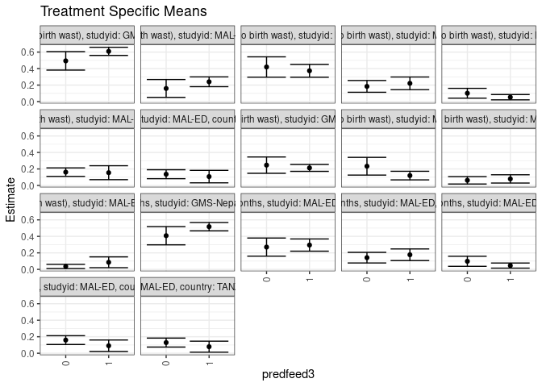

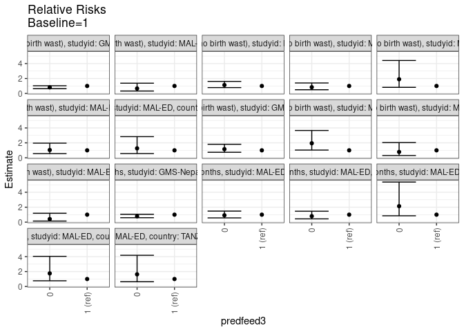

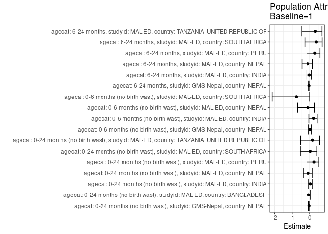

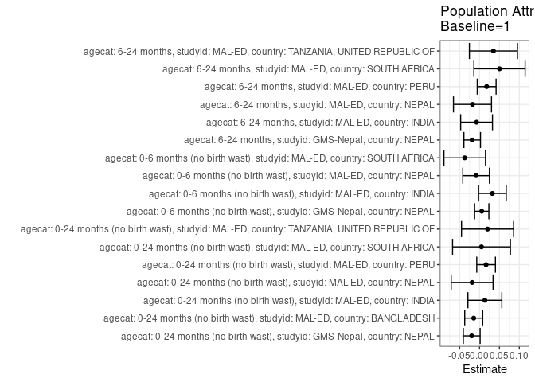

## Results Table

### Parameter: TSM

| agecat | studyid | country | intervention_level | baseline_level | estimate | ci_lower | ci_upper |
| --- | --- | --- | --- | --- | --- | --- | --- |
| 0-24 months (no birth wast) | GMS-Nepal | NEPAL | 1 | NA | 0.6090426 | 0.5596658 | 0.6584193 |
| 0-24 months (no birth wast) | GMS-Nepal | NEPAL | 0 | NA | 0.4935065 | 0.3817131 | 0.6052998 |
| 0-24 months (no birth wast) | MAL-ED | BANGLADESH | 1 | NA | 0.2400000 | 0.1806887 | 0.2993113 |
| 0-24 months (no birth wast) | MAL-ED | BANGLADESH | 0 | NA | 0.1590909 | 0.0507953 | 0.2673865 |
| 0-24 months (no birth wast) | MAL-ED | INDIA | 1 | NA | 0.3733333 | 0.2957451 | 0.4509216 |
| 0-24 months (no birth wast) | MAL-ED | INDIA | 0 | NA | 0.4193548 | 0.2962358 | 0.5424739 |
| 0-24 months (no birth wast) | MAL-ED | NEPAL | 1 | NA | 0.2212389 | 0.1445380 | 0.2979398 |
| 0-24 months (no birth wast) | MAL-ED | NEPAL | 0 | NA | 0.1842105 | 0.1128923 | 0.2555288 |
| 0-24 months (no birth wast) | MAL-ED | PERU | 1 | NA | 0.0531915 | 0.0210564 | 0.0853266 |
| 0-24 months (no birth wast) | MAL-ED | PERU | 0 | NA | 0.1010101 | 0.0415469 | 0.1604733 |
| 0-24 months (no birth wast) | MAL-ED | SOUTH AFRICA | 1 | NA | 0.1549296 | 0.0706075 | 0.2392517 |
| 0-24 months (no birth wast) | MAL-ED | SOUTH AFRICA | 0 | NA | 0.1616162 | 0.1102487 | 0.2129836 |
| 0-24 months (no birth wast) | MAL-ED | TANZANIA, UNITED REPUBLIC OF | 1 | NA | 0.1076923 | 0.0321596 | 0.1832250 |
| 0-24 months (no birth wast) | MAL-ED | TANZANIA, UNITED REPUBLIC OF | 0 | NA | 0.1363636 | 0.0820391 | 0.1906882 |
| 0-6 months (no birth wast) | GMS-Nepal | NEPAL | 1 | NA | 0.2131148 | 0.1711132 | 0.2551163 |
| 0-6 months (no birth wast) | GMS-Nepal | NEPAL | 0 | NA | 0.2465753 | 0.1475887 | 0.3455620 |
| 0-6 months (no birth wast) | MAL-ED | INDIA | 1 | NA | 0.1200000 | 0.0678720 | 0.1721280 |
| 0-6 months (no birth wast) | MAL-ED | INDIA | 0 | NA | 0.2333333 | 0.1260578 | 0.3406089 |
| 0-6 months (no birth wast) | MAL-ED | NEPAL | 1 | NA | 0.0796460 | 0.0296154 | 0.1296766 |
| 0-6 months (no birth wast) | MAL-ED | NEPAL | 0 | NA | 0.0625000 | 0.0175705 | 0.1074295 |
| 0-6 months (no birth wast) | MAL-ED | SOUTH AFRICA | 1 | NA | 0.0857143 | 0.0200123 | 0.1514163 |
| 0-6 months (no birth wast) | MAL-ED | SOUTH AFRICA | 0 | NA | 0.0353535 | 0.0095827 | 0.0611243 |
| 6-24 months | GMS-Nepal | NEPAL | 1 | NA | 0.5173333 | 0.4667015 | 0.5679651 |
| 6-24 months | GMS-Nepal | NEPAL | 0 | NA | 0.4078947 | 0.2972841 | 0.5185054 |
| 6-24 months | MAL-ED | INDIA | 1 | NA | 0.2945205 | 0.2204044 | 0.3686367 |
| 6-24 months | MAL-ED | INDIA | 0 | NA | 0.2698413 | 0.1599705 | 0.3797120 |
| 6-24 months | MAL-ED | NEPAL | 1 | NA | 0.1769912 | 0.1064651 | 0.2475172 |
| 6-24 months | MAL-ED | NEPAL | 0 | NA | 0.1415929 | 0.0771702 | 0.2060157 |
| 6-24 months | MAL-ED | PERU | 1 | NA | 0.0457143 | 0.0147109 | 0.0767177 |
| 6-24 months | MAL-ED | PERU | 0 | NA | 0.0978261 | 0.0370068 | 0.1586454 |
| 6-24 months | MAL-ED | SOUTH AFRICA | 1 | NA | 0.0909091 | 0.0214129 | 0.1604052 |
| 6-24 months | MAL-ED | SOUTH AFRICA | 0 | NA | 0.1593407 | 0.1060608 | 0.2126205 |
| 6-24 months | MAL-ED | TANZANIA, UNITED REPUBLIC OF | 1 | NA | 0.0793651 | 0.0124579 | 0.1462723 |
| 6-24 months | MAL-ED | TANZANIA, UNITED REPUBLIC OF | 0 | NA | 0.1292517 | 0.0748903 | 0.1836131 |

### Parameter: E(Y)

| agecat | studyid | country | intervention_level | baseline_level | estimate | ci_lower | ci_upper |
| --- | --- | --- | --- | --- | --- | --- | --- |
| 0-24 months (no birth wast) | GMS-Nepal | NEPAL | NA | NA | 0.5894040 | 0.5440524 | 0.6347556 |
| 0-24 months (no birth wast) | MAL-ED | BANGLADESH | NA | NA | 0.2254098 | 0.1728726 | 0.2779471 |
| 0-24 months (no birth wast) | MAL-ED | INDIA | NA | NA | 0.3867925 | 0.3210797 | 0.4525052 |
| 0-24 months (no birth wast) | MAL-ED | NEPAL | NA | NA | 0.2026432 | 0.1502365 | 0.2550498 |
| 0-24 months (no birth wast) | MAL-ED | PERU | NA | NA | 0.0696864 | 0.0401775 | 0.0991954 |
| 0-24 months (no birth wast) | MAL-ED | SOUTH AFRICA | NA | NA | 0.1598513 | 0.1159763 | 0.2037263 |
| 0-24 months (no birth wast) | MAL-ED | TANZANIA, UNITED REPUBLIC OF | NA | NA | 0.1278539 | 0.0835266 | 0.1721812 |
| 0-6 months (no birth wast) | GMS-Nepal | NEPAL | NA | NA | 0.2186788 | 0.1799683 | 0.2573894 |
| 0-6 months (no birth wast) | MAL-ED | INDIA | NA | NA | 0.1523810 | 0.1036572 | 0.2011047 |
| 0-6 months (no birth wast) | MAL-ED | NEPAL | NA | NA | 0.0711111 | 0.0374542 | 0.1047681 |
| 0-6 months (no birth wast) | MAL-ED | SOUTH AFRICA | NA | NA | 0.0485075 | 0.0227384 | 0.0742766 |
| 6-24 months | GMS-Nepal | NEPAL | NA | NA | 0.4988914 | 0.4526947 | 0.5450880 |
| 6-24 months | MAL-ED | INDIA | NA | NA | 0.2870813 | 0.2256006 | 0.3485621 |
| 6-24 months | MAL-ED | NEPAL | NA | NA | 0.1592920 | 0.1114757 | 0.2071084 |
| 6-24 months | MAL-ED | PERU | NA | NA | 0.0636704 | 0.0343284 | 0.0930125 |
| 6-24 months | MAL-ED | SOUTH AFRICA | NA | NA | 0.1411290 | 0.0977108 | 0.1845472 |
| 6-24 months | MAL-ED | TANZANIA, UNITED REPUBLIC OF | NA | NA | 0.1142857 | 0.0711519 | 0.1574195 |

### Parameter: RR

| agecat | studyid | country | intervention_level | baseline_level | estimate | ci_lower | ci_upper |
| --- | --- | --- | --- | --- | --- | --- | --- |
| 0-24 months (no birth wast) | GMS-Nepal | NEPAL | 1 | 1 | 1.0000000 | 1.0000000 | 1.000000 |
| 0-24 months (no birth wast) | GMS-Nepal | NEPAL | 0 | 1 | 0.8102989 | 0.6370218 | 1.030709 |
| 0-24 months (no birth wast) | MAL-ED | BANGLADESH | 1 | 1 | 1.0000000 | 1.0000000 | 1.000000 |
| 0-24 months (no birth wast) | MAL-ED | BANGLADESH | 0 | 1 | 0.6628788 | 0.3213097 | 1.367554 |
| 0-24 months (no birth wast) | MAL-ED | INDIA | 1 | 1 | 1.0000000 | 1.0000000 | 1.000000 |
| 0-24 months (no birth wast) | MAL-ED | INDIA | 0 | 1 | 1.1232719 | 0.7839117 | 1.609543 |
| 0-24 months (no birth wast) | MAL-ED | NEPAL | 1 | 1 | 1.0000000 | 1.0000000 | 1.000000 |
| 0-24 months (no birth wast) | MAL-ED | NEPAL | 0 | 1 | 0.8326316 | 0.4951678 | 1.400082 |
| 0-24 months (no birth wast) | MAL-ED | PERU | 1 | 1 | 1.0000000 | 1.0000000 | 1.000000 |
| 0-24 months (no birth wast) | MAL-ED | PERU | 0 | 1 | 1.8989899 | 0.8169289 | 4.414292 |
| 0-24 months (no birth wast) | MAL-ED | SOUTH AFRICA | 1 | 1 | 1.0000000 | 1.0000000 | 1.000000 |
| 0-24 months (no birth wast) | MAL-ED | SOUTH AFRICA | 0 | 1 | 1.0431589 | 0.5554282 | 1.959174 |
| 0-24 months (no birth wast) | MAL-ED | TANZANIA, UNITED REPUBLIC OF | 1 | 1 | 1.0000000 | 1.0000000 | 1.000000 |
| 0-24 months (no birth wast) | MAL-ED | TANZANIA, UNITED REPUBLIC OF | 0 | 1 | 1.2662338 | 0.5652023 | 2.836768 |
| 0-6 months (no birth wast) | GMS-Nepal | NEPAL | 1 | 1 | 1.0000000 | 1.0000000 | 1.000000 |
| 0-6 months (no birth wast) | GMS-Nepal | NEPAL | 0 | 1 | 1.1570074 | 0.7397982 | 1.809502 |
| 0-6 months (no birth wast) | MAL-ED | INDIA | 1 | 1 | 1.0000000 | 1.0000000 | 1.000000 |
| 0-6 months (no birth wast) | MAL-ED | INDIA | 0 | 1 | 1.9444444 | 1.0329938 | 3.660103 |
| 0-6 months (no birth wast) | MAL-ED | NEPAL | 1 | 1 | 1.0000000 | 1.0000000 | 1.000000 |
| 0-6 months (no birth wast) | MAL-ED | NEPAL | 0 | 1 | 0.7847222 | 0.3020750 | 2.038530 |
| 0-6 months (no birth wast) | MAL-ED | SOUTH AFRICA | 1 | 1 | 1.0000000 | 1.0000000 | 1.000000 |
| 0-6 months (no birth wast) | MAL-ED | SOUTH AFRICA | 0 | 1 | 0.4124579 | 0.1432147 | 1.187878 |
| 6-24 months | GMS-Nepal | NEPAL | 1 | 1 | 1.0000000 | 1.0000000 | 1.000000 |
| 6-24 months | GMS-Nepal | NEPAL | 0 | 1 | 0.7884563 | 0.5909797 | 1.051920 |
| 6-24 months | MAL-ED | INDIA | 1 | 1 | 1.0000000 | 1.0000000 | 1.000000 |
| 6-24 months | MAL-ED | INDIA | 0 | 1 | 0.9162052 | 0.5676938 | 1.478671 |
| 6-24 months | MAL-ED | NEPAL | 1 | 1 | 1.0000000 | 1.0000000 | 1.000000 |
| 6-24 months | MAL-ED | NEPAL | 0 | 1 | 0.8000000 | 0.4369436 | 1.464720 |
| 6-24 months | MAL-ED | PERU | 1 | 1 | 1.0000000 | 1.0000000 | 1.000000 |
| 6-24 months | MAL-ED | PERU | 0 | 1 | 2.1399457 | 0.8527742 | 5.369965 |
| 6-24 months | MAL-ED | SOUTH AFRICA | 1 | 1 | 1.0000000 | 1.0000000 | 1.000000 |
| 6-24 months | MAL-ED | SOUTH AFRICA | 0 | 1 | 1.7527473 | 0.7609377 | 4.037286 |
| 6-24 months | MAL-ED | TANZANIA, UNITED REPUBLIC OF | 1 | 1 | 1.0000000 | 1.0000000 | 1.000000 |
| 6-24 months | MAL-ED | TANZANIA, UNITED REPUBLIC OF | 0 | 1 | 1.6285714 | 0.6348173 | 4.177966 |

### Parameter: PAR

| agecat | studyid | country | intervention_level | baseline_level | estimate | ci_lower | ci_upper |
| --- | --- | --- | --- | --- | --- | --- | --- |
| 0-24 months (no birth wast) | GMS-Nepal | NEPAL | 1 | NA | -0.0196386 | -0.0407937 | 0.0015165 |
| 0-24 months (no birth wast) | MAL-ED | BANGLADESH | 1 | NA | -0.0145902 | -0.0371968 | 0.0080165 |
| 0-24 months (no birth wast) | MAL-ED | INDIA | 1 | NA | 0.0134591 | -0.0291944 | 0.0561127 |
| 0-24 months (no birth wast) | MAL-ED | NEPAL | 1 | NA | -0.0185958 | -0.0712491 | 0.0340575 |
| 0-24 months (no birth wast) | MAL-ED | PERU | 1 | NA | 0.0164949 | -0.0069688 | 0.0399586 |
| 0-24 months (no birth wast) | MAL-ED | SOUTH AFRICA | 1 | NA | 0.0049217 | -0.0677548 | 0.0775983 |
| 0-24 months (no birth wast) | MAL-ED | TANZANIA, UNITED REPUBLIC OF | 1 | NA | 0.0201616 | -0.0452865 | 0.0856097 |
| 0-6 months (no birth wast) | GMS-Nepal | NEPAL | 1 | NA | 0.0055641 | -0.0123546 | 0.0234828 |
| 0-6 months (no birth wast) | MAL-ED | INDIA | 1 | NA | 0.0323810 | -0.0023960 | 0.0671579 |
| 0-6 months (no birth wast) | MAL-ED | NEPAL | 1 | NA | -0.0085349 | -0.0420262 | 0.0249564 |
| 0-6 months (no birth wast) | MAL-ED | SOUTH AFRICA | 1 | NA | -0.0372068 | -0.0894158 | 0.0150022 |
| 6-24 months | GMS-Nepal | NEPAL | 1 | NA | -0.0184420 | -0.0392879 | 0.0024040 |
| 6-24 months | MAL-ED | INDIA | 1 | NA | -0.0074392 | -0.0474188 | 0.0325403 |
| 6-24 months | MAL-ED | NEPAL | 1 | NA | -0.0176991 | -0.0655155 | 0.0301172 |
| 6-24 months | MAL-ED | PERU | 1 | NA | 0.0179561 | -0.0057536 | 0.0416659 |
| 6-24 months | MAL-ED | SOUTH AFRICA | 1 | NA | 0.0502199 | -0.0141555 | 0.1145954 |
| 6-24 months | MAL-ED | TANZANIA, UNITED REPUBLIC OF | 1 | NA | 0.0349206 | -0.0255041 | 0.0953454 |

### Parameter: PAF

| agecat | studyid | country | intervention_level | baseline_level | estimate | ci_lower | ci_upper |
| --- | --- | --- | --- | --- | --- | --- | --- |
| 0-24 months (no birth wast) | GMS-Nepal | NEPAL | 1 | NA | -0.0333194 | -0.0700284 | 0.0021303 |
| 0-24 months (no birth wast) | MAL-ED | BANGLADESH | 1 | NA | -0.0647273 | -0.1694188 | 0.0305918 |
| 0-24 months (no birth wast) | MAL-ED | INDIA | 1 | NA | 0.0347967 | -0.0820633 | 0.1390362 |
| 0-24 months (no birth wast) | MAL-ED | NEPAL | 1 | NA | -0.0917661 | -0.3845115 | 0.1390804 |
| 0-24 months (no birth wast) | MAL-ED | PERU | 1 | NA | 0.2367021 | -0.1657289 | 0.5002066 |
| 0-24 months (no birth wast) | MAL-ED | SOUTH AFRICA | 1 | NA | 0.0307894 | -0.5492478 | 0.3936611 |
| 0-24 months (no birth wast) | MAL-ED | TANZANIA, UNITED REPUBLIC OF | 1 | NA | 0.1576923 | -0.5426579 | 0.5400910 |
| 0-6 months (no birth wast) | GMS-Nepal | NEPAL | 1 | NA | 0.0254440 | -0.0599789 | 0.1039827 |
| 0-6 months (no birth wast) | MAL-ED | INDIA | 1 | NA | 0.2125000 | -0.0424331 | 0.4050877 |
| 0-6 months (no birth wast) | MAL-ED | NEPAL | 1 | NA | -0.1200221 | -0.7011560 | 0.2625900 |
| 0-6 months (no birth wast) | MAL-ED | SOUTH AFRICA | 1 | NA | -0.7670330 | -2.1314677 | 0.0028939 |
| 6-24 months | GMS-Nepal | NEPAL | 1 | NA | -0.0369659 | -0.0797589 | 0.0041311 |
| 6-24 months | MAL-ED | INDIA | 1 | NA | -0.0259132 | -0.1750479 | 0.1042936 |
| 6-24 months | MAL-ED | NEPAL | 1 | NA | -0.1111111 | -0.4543451 | 0.1511176 |
| 6-24 months | MAL-ED | PERU | 1 | NA | 0.2820168 | -0.1711767 | 0.5598445 |
| 6-24 months | MAL-ED | SOUTH AFRICA | 1 | NA | 0.3558442 | -0.2866629 | 0.6775093 |
| 6-24 months | MAL-ED | TANZANIA, UNITED REPUBLIC OF | 1 | NA | 0.3055556 | -0.4647664 | 0.6707645 |